# Quickstart Guide: zztab2fig v0.2.0

Ronald G. Thomas

This quickstart guide covers the key features in zztab2fig v0.2.0. For complete documentation, see the “Object Types and Themes” and “Advanced Features” vignettes.

## Installation

```r
# Install from GitHub
# devtools::install_github("rgt47/zztab2fig")
```

```r
library(zztab2fig)
```

## Basic Usage

Convert a data frame to a cropped PDF table:

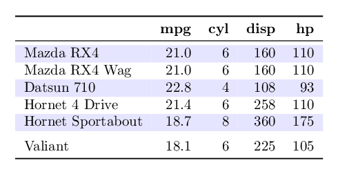

```r
t2f(mtcars[1:6, 1:4], filename = "basic_table", sub_dir = output_dir)
```

This generates three files:

- `basic_table.tex` - LaTeX source
- `basic_table.pdf` - Full PDF
- `basic_table_cropped.pdf` - Cropped PDF for document inclusion

## Journal Themes

Built-in themes provide journal-specific styling:

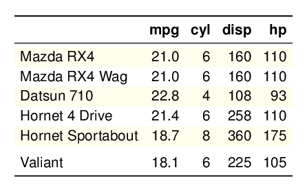

```r
t2f(mtcars[1:6, 1:4], theme = "nejm",
    filename = "nejm_table", sub_dir = output_dir)
```

Available themes: `"nejm"`, `"apa"`, `"nature"`, `"minimal"`

Set a global theme:

```r
t2f_theme_set("nejm")
t2f(mtcars[1:6, 1:4])
t2f(iris[1:6, ])
```

## Statistical Objects

t2f works directly with statistical objects:

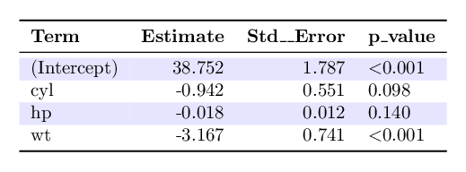

```r
model <- lm(mpg ~ cyl + hp + wt, data = mtcars)
t2f(model, filename = "regression", sub_dir = output_dir,
    include = c("estimate", "std.error", "p.value"))
```

## Inline Tables for R Markdown

Insert tables directly in R Markdown without LaTeX float positioning:

```r
model <- lm(mpg ~ cyl + hp, data = mtcars)
t2f_inline(model,
           width = "3in",
           align = "left",
           caption = "Model Results",
           label = "tab:model",
           caption_position = "above")
```

Or use the convenience function for coefficient tables:

```r
t2f_coef(model, caption = "Coefficients")
```

Add visual styling with frames and backgrounds:

```r
t2f_inline(model,
           width = "3in",
           frame = TRUE,
           frame_color = "gray",
           background = "gray!5",
           inner_sep = "4pt")
```

**Note**: Add `\usepackage{caption}` to your R Markdown YAML for captions.

## Model Comparison

Compare multiple models side-by-side:

```r
m1 <- lm(mpg ~ cyl, data = mtcars)
m2 <- lm(mpg ~ cyl + hp, data = mtcars)
m3 <- lm(mpg ~ cyl + hp + wt, data = mtcars)

t2f_regression(
  Model1 = m1, Model2 = m2, Model3 = m3,
  stars = TRUE,
  filename = "model_comparison",
  sub_dir = output_dir
)
```

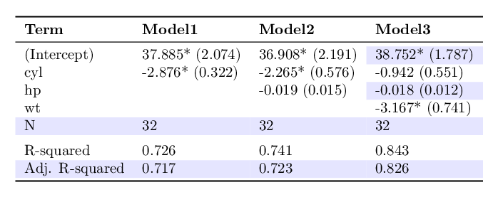

## Captions and Labels

Add LaTeX captions and cross-reference labels:

```r
t2f(mtcars[1:6, 1:4],
    caption = "Motor Trend Car Road Tests (1974)",
    label = "tab:mtcars",
    filename = "captioned_table")
```

## Column Alignment

Explicit or auto-detected alignment:

```r
t2f(iris[1:6, ], align = NULL)
t2f(mtcars[1:6, 1:4], align = c("l", "r", "r", "r"))
t2f(mtcars[1:6, 1:4], align = "c")
```

## Decimal Alignment

Use siunitx for decimal-aligned columns:

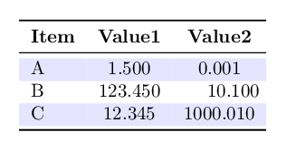

```r
df <- data.frame(
  Item = c("A", "B", "C"),
  Value1 = c(1.5, 123.45, 12.345),
  Value2 = c(0.001, 10.1, 1000.01)
)

t2f(df, filename = "decimal_aligned", sub_dir = output_dir,
    align = list("l", t2f_siunitx(table_format = "3.3"),
                 t2f_siunitx(table_format = "4.2")))
```

## Multi-Page Tables

For large tables that span multiple pages:

```r
t2f(mtcars,
    longtable = TRUE,
    caption = "Complete mtcars Dataset",
    filename = "long_table")
```

## Quick Reference

### Key t2f() Parameters

| Parameter | Description | Default |
| --- | --- | --- |
| `caption` | LaTeX table caption | NULL |
| `label` | LaTeX label for cross-refs | NULL |
| `align` | Column alignment (l/c/r) | NULL (auto) |
| `longtable` | Multi-page table support | FALSE |
| `crop` | Crop PDF margins | TRUE |
| `crop_margin` | Margin size (pts) | 10 |
| `theme` | Theme name or object | NULL |

### Key t2f_inline() Parameters

| Parameter | Description | Default |
| --- | --- | --- |
| `width` | Figure width (LaTeX units) | NULL |
| `align` | left, center, right | “center” |
| `caption` | Uses \captionof (no float) | NULL |
| `label` | LaTeX cross-reference label | NULL |
| `caption_position` | “above” or “below” | “above” |
| `frame` | Draw border around table | FALSE |
| `frame_color` | Border color (xcolor syntax) | “black” |
| `background` | Background color (xcolor syntax) | NULL |
| `inner_sep` | Padding inside frame | “2pt” |
| `format` | “auto”, “pdf”, “png” | “auto” |

### Core Functions

| Function | Purpose |
| --- | --- |
| `t2f()` | Convert object to PDF table |
| `t2f_inline()` | Inline tables for R Markdown |
| `t2f_coef()` | Quick coefficient tables |
| `t2f_regression()` | Compare regression models |
| `t2f_theme_set()` | Set global theme |
| `t2f_theme_get()` | Get current theme |
| `check_latex_deps()` | Check LaTeX dependencies |
| `ensure_pdfcrop()` | Install pdfcrop via TinyTeX |

### S3 Methods (Base)

| Object Type | Method |
| --- | --- |
| `data.frame` | `t2f.data.frame()` |
| `matrix` | `t2f.matrix()` |
| `lm` | `t2f.lm()` |
| `glm` | `t2f.glm()` |
| `anova` / `aov` | `t2f.anova()` / `t2f.aov()` |
| `htest` | `t2f.htest()` |

### S3 Methods (via broom)

| Object Type | Package |
| --- | --- |
| `coxph`, `survreg`, `survfit` | survival |
| `nls` | stats |
| `polr`, `multinom` | MASS, nnet |
| `prcomp`, `kmeans` | stats |
| `lmerMod`, `glmerMod` | lme4 |
| `lme` | nlme |
| `Arima` | stats |

### Theme Presets

| Function | Style |
| --- | --- |
| `t2f_theme_nejm()` | NEJM (medical journals) |
| `t2f_theme_apa()` | APA (psychology) |
| `t2f_theme_nature()` | Nature (scientific) |
| `t2f_theme_minimal()` | Clean, minimal |

## System Requirements

- R >= 4.0
- LaTeX distribution (TeX Live, MiKTeX, TinyTeX, or MacTeX)
- `pdflatex` and `pdfcrop` executables
- Optional: ImageMagick (for PNG output)

Check your setup:

```r
check_latex_deps()
```

If pdfcrop is missing with TinyTeX:

```r
ensure_pdfcrop(auto_install = TRUE)
```